# Juvenile Brown Trout Survival & Emigration Dynamics

Upper Clark Fork River — Mark-Recapture Power Analysis

Published

March 15, 2026

## Overview

This document presents a simulation-based power analysis for a juvenile brown trout (*Salmo trutta*) survival study on the Upper Clark Fork River, Montana. The study uses PIT (Passive Integrated Transponder) tagging combined with stationary antenna arrays and electrofishing recapture surveys to estimate reach-specific survival and emigration dynamics.

**Core scientific questions:**

1. Is survival of juvenile brown trout in the mainstem low enough to be a demographic bottleneck?
2. Are fish emigrating from tributaries permanently leaving the upper river, or do they remain in the mainstem and contribute to the resident population?

The power analysis asks: *how many fish need to be tagged to answer these questions with acceptable precision?*

## Study System

### Spatial Layout

The monitoring network spans approximately 20 river miles of the upper Clark Fork, anchored by three mainstem PIT antenna arrays and three tributary mouth antennas.

```
flowchart TD
    T["**State 1**\nAlive in Tributary\n*(tribs 1, 2, 3 lumped)*"]
    M["**State 2**\nAlive in Mainstem\nWarm Springs – Gembeck Rd\n*(primary study area)*"]
    L["**State 3**\nAlive in Mainstem\nGembeck Rd – Sager Ln\n*(secondary study area)*"]
    PS["**State 4**\nEmigrated past Sager Ln\n*(absorbing)*"]
    PW["**State 5**\nEmigrated past Warm Springs\n*(absorbing)*"]
    D["**State 6**\nDead\n*(absorbing)*"]

    T -- "Trib antenna\n*p_trib ≈ 0.93*" --> M
    M -- "Trib antenna\n*p_trib ≈ 0.93*" --> T
    M -- "Gembeck antenna\n*p_gem ≈ 0.76*" --> L
    L -- "Sager antenna\n*p_sag ≈ 0.76*" --> PS
    M -- "WS antenna\n*p_ws ≈ 0.76*" --> PW
    T --> D
    M --> D
    L --> D

    style T  fill:#d4ecd4,stroke:#4a7c4a
    style M  fill:#d0e4f7,stroke:#3a6ea8
    style L  fill:#e8d8f0,stroke:#7a4a9a
    style PS fill:#f5e6c8,stroke:#a07030
    style PW fill:#f5e6c8,stroke:#a07030
    style D  fill:#f0d0d0,stroke:#a03030
```

Study system schematic. Boxes represent states in the statistical model; arrows show allowed transitions with the antenna that fires on each crossing.

### Antenna Design and Detection Efficiency

All antenna detections are transition-based. The Gembeck + Sager antenna pair constitutes a double-observer system for downstream emigrants, allowing detection efficiency at Gembeck to be estimated from the data rather than assumed.

Table 1: Monitoring infrastructure and pilot-estimated detection probabilities.

| Location | Type | Detection model | Pilot estimate |
| --- | --- | --- | --- |
| Trib 1, 2, 3 mouth antennas | Passive PIT | Transition: states 1 ↔︎ 2 | 0.93 |
| Warm Springs (mainstem) | Passive PIT | Transition: state 2 → 5 | 0.76 (assumed) |
| Gembeck Rd (mainstem) | Passive PIT | Transition: state 2 → 3 | 0.76 |
| Sager Ln (mainstem) | Passive PIT | Transition: state 3 → 4 | 0.76 (assumed) |
| Electrofishing (mainstem) | Active recapture | Proximity: state 2 | 0.15 – 0.35 |

## Statistical Model

### Hidden Markov Model Structure

Fish fate is modeled as a Hidden Markov Model (HMM) in which the true state $z_{i,t}$ (alive in a given reach, or dead) evolves according to a Markov transition matrix and is observed imperfectly through the antenna and electrofishing detection process.

At each occasion $t$, the state of fish $i$ evolves as:

$$z_{i,t} \sim \text{Categorical}(\mathbf{T}_{z_{i,t-1},\cdot})$$

where $\mathbf{T}$ is the $6 \times 6$ transition matrix parameterized by reach-specific survival ($\phi$) and movement probabilities ($\psi$). The initial state $z_{i,1}$ is known from the tagging location.

### Transition Matrix

Movement from the primary study area (state 2) uses a Dirichlet parameterization to ensure that the three directional probabilities (return to trib, downstream, upstream) sum to $\leq 1$:

$$\psi_{\text{back}}, \psi_{\text{down}}, \psi_{\text{up}} = \psi_{\text{move}} \times \text{Dir}(\alpha_1, \alpha_2, \alpha_3)$$

### Detection Priors

Detection probability priors are **logit-normal**, centered on pilot estimates when informative priors are requested:

$$\text{logit}(p) \sim \mathcal{N}(\mu, \sigma^2)$$

| Prior type | $\mu$ | $\sigma$ (logit scale) |
| --- | --- | --- |
| Informative | $\text{logit}(\hat{p}_\text{pilot})$ | 0.30 |
| Vague | 0 | 5.00 |

Toggling between prior types requires only a change in the data passed to JAGS.

### JAGS Model

```r
model {

  # ======================================================
  # Multi-state survival model: Upper Clark Fork Brown Trout
  #
  # States:
  #   1 = Alive in tributary (tribs 1, 2, 3 lumped)
  #   2 = Alive in mainstem Warm Springs - Gembeck Rd    (primary study area)
  #   3 = Alive in mainstem Gembeck Rd - Sager Ln        (secondary study area)
  #   4 = Emigrated downstream past Sager Ln             (absorbing)
  #   5 = Emigrated upstream past Warm Springs           (absorbing)
  #   6 = Dead                                           (absorbing)
  #
  # All antenna detection is TRANSITION-based (fires when a fish crosses
  # a specific antenna boundary, not just when it is nearby):
  #
  #   Trib antennas  (p_trib): 1 <-> 2  crossing (either direction)
  #   Gembeck antenna (p_gem): 2  ->  3  crossing (downstream only)
  #   Warm Springs ant (p_ws): 2  ->  5  crossing (upstream only)
  #   Sager Ln antenna (p_sag): 3  ->  4  crossing (downstream only)
  #
  # Active sampling:
  #   Electrofishing (p_efish): PROXIMITY-based, detects fish in state 2
  #
  # Detection probability priors:
  #   Logit-normal with hyperparameters passed as data. This allows toggling
  #   between informative priors (from pilot data) and vague priors simply
  #   by changing the data passed to the model — no model edits needed.
  #
  #   Informative: mu = qlogis(empirical estimate), sd = 0.3 (logit scale)
  #   Vague:       mu = 0,                          sd = 5.0 (logit scale)
  # ======================================================

  # ---- Priors: survival ----
  phi_trib  ~ dbeta(1, 1)   # per-occasion survival in tributaries
  phi_main  ~ dbeta(1, 1)   # per-occasion survival in mainstem WS-Gembeck
  phi_lower ~ dbeta(1, 1)   # per-occasion survival in mainstem Gembeck-Sager

  # ---- Priors: movement ----

  # From trib (state 1): probability of emigrating to mainstem per occasion
  psi_trib_out ~ dbeta(1, 1)

  # From mainstem WS-Gembeck (state 2):
  #   psi_main_move = overall probability of leaving state 2 per occasion
  #   dir_main[1:3] ~ Dirichlet = directional split of movement
  #     dir_main[1] -> back to trib    (state 2 -> 1)
  #     dir_main[2] -> downstream      (state 2 -> 3, Gembeck antenna fires)
  #     dir_main[3] -> upstream        (state 2 -> 5, WS antenna fires)
  psi_main_move  ~ dbeta(1, 1)
  dir_main[1:3] ~ ddirch(dir_alpha[1:3])

  psi_main_back <- psi_main_move * dir_main[1]
  psi_main_down <- psi_main_move * dir_main[2]
  psi_main_up   <- psi_main_move * dir_main[3]

  # From mainstem Gembeck-Sager (state 3):
  #   psi_sager = probability of passing Sager Ln per occasion
  #   (Sager antenna fires on this transition)
  psi_sager ~ dbeta(1, 1)

  # ---- Priors: detection (logit-normal, hyperparameters supplied as data) ----
  # Hyperparameter names: p_X_mu (mean on logit scale), p_X_sd (SD on logit scale)
  # Informative: center on pilot estimates, sd = 0.3 (logit scale)
  # Vague:       mu = 0, sd = 5 (logit scale, ~flat on probability scale)

  p_trib_logit ~ dnorm(p_trib_mu,  pow(p_trib_sd,  -2))
  p_gem_logit  ~ dnorm(p_gem_mu,   pow(p_gem_sd,   -2))
  p_ws_logit   ~ dnorm(p_ws_mu,    pow(p_ws_sd,    -2))
  p_sag_logit  ~ dnorm(p_sag_mu,   pow(p_sag_sd,   -2))
  p_efish_logit ~ dnorm(p_efish_mu, pow(p_efish_sd, -2))

  p_trib  <- ilogit(p_trib_logit)
  p_gem   <- ilogit(p_gem_logit)
  p_ws    <- ilogit(p_ws_logit)
  p_sag   <- ilogit(p_sag_logit)
  p_efish <- ilogit(p_efish_logit)

  # ======================================================
  # Transition matrix  tr[current_state, next_state]
  # ======================================================

  # From state 1 (alive in tributary)
  tr[1, 1] <- phi_trib * (1 - psi_trib_out)
  tr[1, 2] <- phi_trib * psi_trib_out
  tr[1, 3] <- 0
  tr[1, 4] <- 0
  tr[1, 5] <- 0
  tr[1, 6] <- 1 - phi_trib

  # From state 2 (alive in mainstem WS-Gembeck)
  tr[2, 1] <- phi_main * psi_main_back
  tr[2, 2] <- phi_main * (1 - psi_main_back - psi_main_down - psi_main_up)
  tr[2, 3] <- phi_main * psi_main_down
  tr[2, 4] <- 0
  tr[2, 5] <- phi_main * psi_main_up
  tr[2, 6] <- 1 - phi_main

  # From state 3 (alive in mainstem Gembeck-Sager)
  tr[3, 1] <- 0
  tr[3, 2] <- 0
  tr[3, 3] <- phi_lower * (1 - psi_sager)
  tr[3, 4] <- phi_lower * psi_sager
  tr[3, 5] <- 0
  tr[3, 6] <- 1 - phi_lower

  # From state 4 (emigrated past Sager; absorbing)
  tr[4, 1] <- 0
  tr[4, 2] <- 0
  tr[4, 3] <- 0
  tr[4, 4] <- 1
  tr[4, 5] <- 0
  tr[4, 6] <- 0

  # From state 5 (emigrated upstream past WS; absorbing)
  tr[5, 1] <- 0
  tr[5, 2] <- 0
  tr[5, 3] <- 0
  tr[5, 4] <- 0
  tr[5, 5] <- 1
  tr[5, 6] <- 0

  # From state 6 (dead; absorbing)
  tr[6, 1] <- 0
  tr[6, 2] <- 0
  tr[6, 3] <- 0
  tr[6, 4] <- 0
  tr[6, 5] <- 0
  tr[6, 6] <- 1

  # ======================================================
  # Likelihood
  # ======================================================

  for(i in 1:n_fish) {

    # Initial state known from tagging location (supplied as data)
    z[i, 1] <- z_init[i]

    # Hidden state process
    for(t in 2:n_occ) {
      z[i, t] ~ dcat(tr[z[i, t-1], 1:6])
    }

    # Observation process
    for(t in 2:n_occ) {

      # -- Trib antenna: fires on any 1<->2 crossing --
      crossed_trib[i, t] <- equals(z[i, t-1], 1) * equals(z[i, t], 2) +
                             equals(z[i, t-1], 2) * equals(z[i, t], 1)
      y_trib[i, t] ~ dbern(p_trib * crossed_trib[i, t])

      # -- Gembeck antenna: fires on 2->3 downstream crossing --
      y_gem[i, t] ~ dbern(p_gem * equals(z[i, t-1], 2) * equals(z[i, t], 3))

      # -- Warm Springs antenna: fires on 2->5 upstream crossing --
      y_ws[i, t] ~ dbern(p_ws * equals(z[i, t-1], 2) * equals(z[i, t], 5))

      # -- Sager Ln antenna: fires on 3->4 downstream crossing --
      # Fish detected here could NOT have been detected at Gembeck (state 2->3)
      # at this occasion, so the joint likelihood across occasions allows
      # estimation of p_gem from the data via the double-observer structure.
      y_sag[i, t] ~ dbern(p_sag * equals(z[i, t-1], 3) * equals(z[i, t], 4))

      # -- Electrofishing: proximity detection in mainstem WS-Gembeck --
      y_efish[i, t] ~ dbern(p_efish * equals(z[i, t], 2))

    }
  }

} # end model
```

## Simulation Design

### Approach

The power analysis uses a **parametric bootstrap** design:

1. Simulate a dataset under known true parameters
2. Fit the JAGS model to the simulated data
3. Record posterior means and SDs for key parameters
4. Repeat 25 times per scenario
5. Summarize bias, precision (posterior SD), and RMSE across replications

Power is assessed by whether the posterior SD is small enough to distinguish biologically meaningful differences.

### True Parameter Values

Table 2: True parameter values used in all simulations (baseline survival scenario). Annual survival is converted to per-occasion survival as φ^(1/5).

[output not shown]

### Scenarios

Table 3: Simulation scenarios. Scenarios 1–7 use informative detection priors from pilot data. Scenarios 8 and 10 repeat key conditions with vague priors to quantify the value of the pilot work.

| Scenario | N tagged | φ (annual) | p_efish | Det. priors | φ (per occ) |
| --- | --- | --- | --- | --- | --- |
| **Vary sample size (baseline survival)** |  |  |  |  |  |
| 1 | 500 | 0.2 | 0.25 | Informative | 0.725 |
| 2 | 1000 | 0.2 | 0.25 | Informative | 0.725 |
| 3 | 2000 | 0.2 | 0.25 | Informative | 0.725 |
| **Vary survival & detection (1000 fish)** |  |  |  |  |  |
| 5 | 1000 | 0.1 | 0.25 | Informative | 0.631 |
| 6 | 1000 | 0.3 | 0.25 | Informative | 0.786 |
| 7 | 1000 | 0.2 | 0.15 | Informative | 0.725 |
| **Vague priors — value of pilot data** |  |  |  |  |  |
| 8 | 1000 | 0.2 | 0.25 | Vague | 0.725 |
| 10 | 1000 | 0.1 | 0.25 | Vague | 0.631 |

## Results

Convergence summary by scenario (Rhat < 1.1 for all monitored parameters).

| Scenario | Label | N tagged | φ annual | Informative priors | Reps converged | % converged |
| --- | --- | --- | --- | --- | --- | --- |
| 1 | 500 | 500 | 0.2 | Yes | 38 | 76 |
| 2 | 1000 | 1000 | 0.2 | Yes | 31 | 62 |
| 3 | 2000 | 2000 | 0.2 | Yes | 21 | 84 |
| 5 | Low φ | 1000 | 0.1 | Yes | 21 | 84 |
| 6 | High φ | 1000 | 0.3 | Yes | 14 | 56 |
| 7 | Low p_efish | 1000 | 0.2 | Yes | 20 | 80 |
| 8 | 1000 (vague) | 1000 | 0.2 | No | 15 | 30 |
| 10 | Low φ (vague) | 1000 | 0.1 | No | 8 | 32 |

### Precision by Sample Size

Posterior standard deviation (SD) measures how precisely each parameter is estimated. Smaller SD = tighter credible intervals.

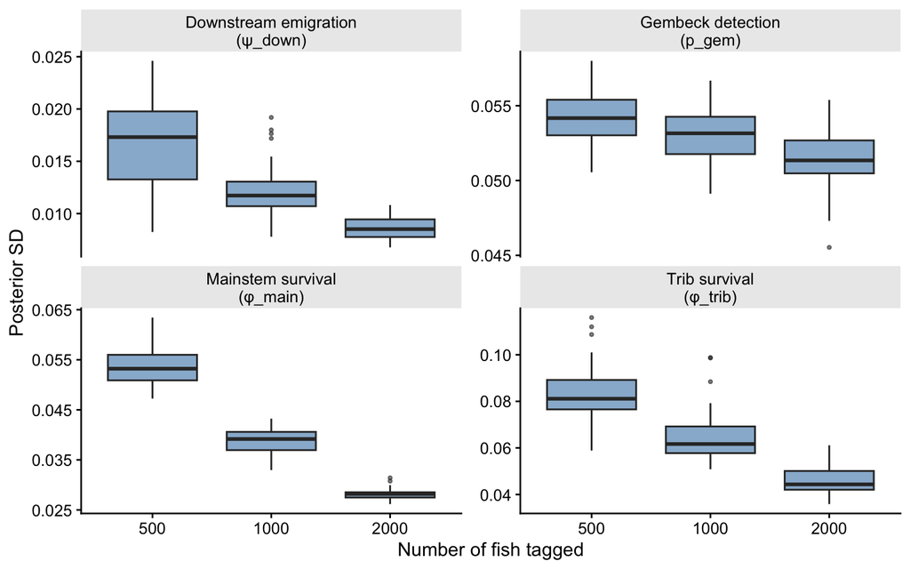

```r
plot_dat <- all_data |>
  filter(scenario %in% c(1, 2, 3)) |>
  select(scenario, n_tagged, label_short,
         `Trib survival\n(φ_trib)`       = phi_trib_sd,
         `Mainstem survival\n(φ_main)`   = phi_main_sd,
         `Downstream emigration\n(ψ_down)` = psi_down_sd,
         `Gembeck detection\n(p_gem)`    = p_gem_sd) |>
  pivot_longer(-(scenario:label_short), names_to = "parameter", values_to = "post_sd") |>
  mutate(n_tagged = factor(n_tagged))

ggplot(plot_dat, aes(x = n_tagged, y = post_sd)) +
  geom_boxplot(fill = "steelblue", alpha = 0.6, outlier.size = 0.8) +
  facet_wrap(~parameter, scales = "free_y", ncol = 2) +
  labs(x = "Number of fish tagged", y = "Posterior SD") +
  theme_cf()
```

### Bias Assessment

Bias is the mean difference between the estimated posterior mean and the known true value. Values near zero indicate the model recovers the truth without systematic over- or under-estimation.

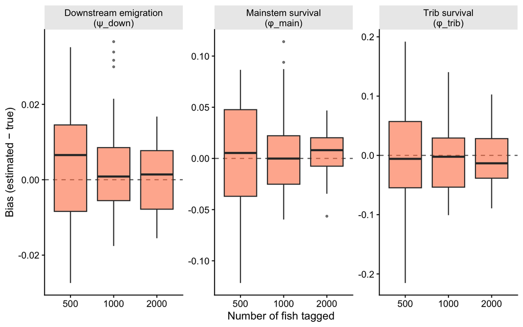

Figure 2: Bias (estimated − true) for survival and downstream emigration across sample size scenarios. Dashed line at zero = no bias.

```r
bias_dat <- all_data |>
  filter(scenario %in% c(1, 2, 3)) |>
  select(scenario, n_tagged,
         `Mainstem survival\n(φ_main)`     = bias_phi_main,
         `Trib survival\n(φ_trib)`          = bias_phi_trib,
         `Downstream emigration\n(ψ_down)`  = bias_psi_down) |>
  pivot_longer(-(scenario:n_tagged), names_to = "parameter", values_to = "bias") |>
  mutate(n_tagged = factor(n_tagged))

ggplot(bias_dat, aes(x = n_tagged, y = bias)) +
  geom_hline(yintercept = 0, linetype = "dashed", colour = "grey40") +
  geom_boxplot(fill = "coral", alpha = 0.6, outlier.size = 0.8) +
  facet_wrap(~parameter, scales = "free_y", ncol = 3) +
  labs(x = "Number of fish tagged", y = "Bias (estimated − true)") +
  theme_cf()
```

### Value of Pilot Detection Data (Prior Sensitivity)

Scenarios 8 and 10 repeat baseline conditions with **vague** priors on detection probabilities. Comparing these against matched informative-prior scenarios quantifies how much the 2023–2025 pilot antenna and electrofishing data are worth in terms of parameter precision.

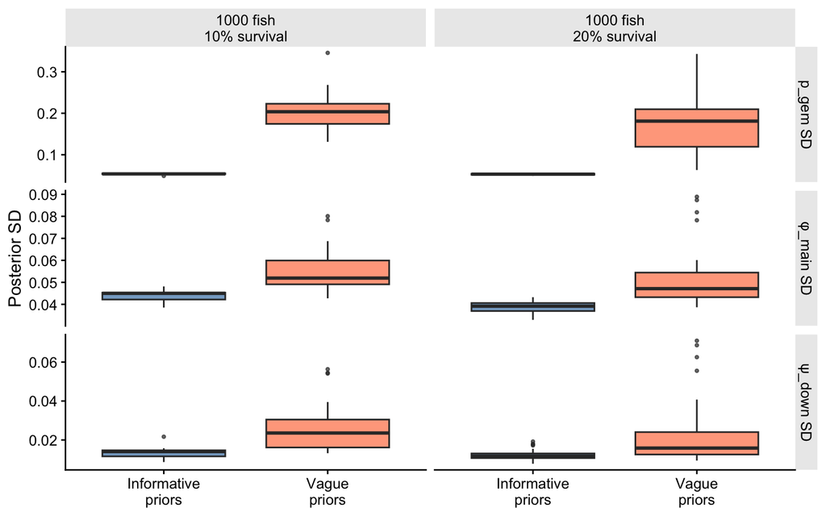

Figure 3: Effect of prior type on posterior SD for key parameters. Each pair of boxplots shares the same n_tagged and true parameter values. ‘Informative’ priors use pilot detection estimates; ‘Vague’ priors are essentially flat.

```r
prior_dat <- all_data |>
  filter(scenario %in% c(2, 5, 8, 10)) |>
  mutate(
    comparison = case_when(
      scenario %in% c(2, 8)  ~ "1000 fish\n20% survival",
      scenario %in% c(5, 10) ~ "1000 fish\n10% survival"
    ),
    prior_label = if_else(use_inform, "Informative\npriors", "Vague\npriors")
  ) |>
  select(comparison, prior_label,
         `φ_main SD`  = phi_main_sd,
         `ψ_down SD`  = psi_down_sd,
         `p_gem SD`   = p_gem_sd) |>
  pivot_longer(-(comparison:prior_label), names_to = "parameter", values_to = "post_sd")

ggplot(prior_dat, aes(x = prior_label, y = post_sd, fill = prior_label)) +
  geom_boxplot(alpha = 0.7, outlier.size = 0.8) +
  facet_grid(parameter ~ comparison, scales = "free_y") +
  scale_fill_manual(values = c("Informative\npriors" = "steelblue",
                                "Vague\npriors"       = "coral"),
                    guide = "none") +
  labs(x = NULL, y = "Posterior SD") +
  theme_cf()
```

### Summary Statistics

```r
all_data |>
  group_by(Scenario = scenario, Label = label_short) |>
  summarise(
    `N reps`        = sum(!is.na(phi_main_mean)),
    `φ_main bias`   = round(mean(bias_phi_main,  na.rm = TRUE), 4),
    `φ_main mean SE`= round(mean(phi_main_sd,    na.rm = TRUE), 4),
    `φ_main RMSE`   = round(sqrt(mean(bias_phi_main^2, na.rm = TRUE)), 4),
    `ψ_down bias`   = round(mean(bias_psi_down,  na.rm = TRUE), 4),
    `ψ_down mean SE`= round(mean(psi_down_sd,    na.rm = TRUE), 4),
    `p_gem mean SE` = round(mean(p_gem_sd,        na.rm = TRUE), 4),
    `% converged`   = round(100 * mean(converged, na.rm = TRUE)),
    .groups = "drop"
  ) |>
  kbl(align = c("c", "l", rep("r", 8))) |>
  kable_styling(bootstrap_options = c("striped", "hover"),
                full_width = TRUE, font_size = 13) |>
  row_spec(0, bold = TRUE)
```

Table 4: Summary of estimation performance across all scenarios. Mean SE = mean posterior SD across replications (precision); RMSE = root mean squared error (combined accuracy + precision); Bias = mean(estimated − true).

| Scenario | Label | N reps | φ_main bias | φ_main mean SE | φ_main RMSE | ψ_down bias | ψ_down mean SE | p_gem mean SE | % converged |
| --- | --- | --- | --- | --- | --- | --- | --- | --- | --- |
| 1 | 500 | 50 | -0.0003 | 0.0536 | 0.0538 | 0.0041 | 0.0168 | 0.0542 | 76 |
| 2 | 1000 | 50 | 0.0026 | 0.0388 | 0.0374 | 0.0027 | 0.0121 | 0.0531 | 62 |
| 3 | 2000 | 25 | 0.0041 | 0.0283 | 0.0253 | 0.0004 | 0.0086 | 0.0514 | 84 |
| 5 | Low φ | 25 | 0.0015 | 0.0440 | 0.0378 | -0.0006 | 0.0136 | 0.0538 | 84 |
| 6 | High φ | 25 | -0.0075 | 0.0366 | 0.0281 | 0.0009 | 0.0111 | 0.0527 | 56 |
| 7 | Low p_efish | 25 | -0.0228 | 0.0492 | 0.0536 | 0.0026 | 0.0132 | 0.0528 | 80 |
| 8 | 1000 (vague) | 50 | 0.0193 | 0.0504 | 0.0475 | 0.0092 | 0.0216 | 0.1698 | 30 |
| 10 | Low φ (vague) | 25 | 0.0002 | 0.0550 | 0.0511 | 0.0084 | 0.0267 | 0.2037 | 32 |

## Recommendations

Based on 62% MCMC convergence and a mean posterior SD of **0.039** for mainstem survival and **0.012** for downstream emigration probability at the 1,000-fish baseline scenario, the following recommendations apply:

**Minimum recommended tagging effort: 1,000 fish**

Below this threshold, emigration estimates become unstable due to the small number of fish passing antennas. At 11–15% emigration, only 110–150 emigrants are expected per 1,000 tagged fish — the lower bound of what the Gembeck/Sager double-observer system needs to reliably estimate detection efficiency.

**Target tagging effort: 2,000–4,000 fish**

Achievable within the spring electrofishing + screw trap design (pilot estimate: 4,000–6,000 fish). This range meaningfully improves precision over the 1,000-fish minimum and provides robustness against poor electrofishing years (p_efish ≈ 0.15).

**Value of pilot detection data**

Informative priors on detection probabilities (from the 2023–2025 pilot work) materially improve estimation of downstream emigration and Gembeck detection efficiency. Vague priors produce noticeably wider posteriors, particularly when survival is low and few fish are available at each antenna.

**Primary study reach: Warm Springs to Gembeck Rd**

The ~11-mile reach between these two mainstem antennas is appropriately sized for boat electrofishing and provides a bounded study area for survival estimation. Extension to the Gembeck–Sager section is worthwhile if tagging targets are met, but the upper reach should be the analytical priority.

## Methods Code

The full simulation and model-fitting code is available in this repository. Simulation is deterministic given the scenario inputs; results reproduce exactly with `set.seed(123)`.

```r
#******************************************************************************
# Power analysis: Upper Clark Fork juvenile brown trout survival study
#
# System: Warm Springs -> Gembeck Rd -> Sager Ln (~11 river miles each)
#         3 tributaries (2 above Gembeck, 1 between Gembeck and Sager)
#         Fish tagged primarily in tributaries
#
# Key scientific questions:
#   1. Is mainstem survival very low?
#   2. Are fish emigrating from tribs permanently leaving the upper river?
#
# Empirical detection estimates (pilot work, 2023-2025):
#   p_trib   : 0.93  (trib mouth antennas; directional)
#   p_gem    : 0.76  (Gembeck Rd mainstem antenna)
#   p_ws     : 0.76  (Warm Springs mainstem antenna)
#   p_sag    : 0.76  (Sager Ln mainstem antenna)
#   p_efish  : 0.15-0.35 (barge/boat electrofishing)
#
# Survival expectation: 10-30% annual
#   -> per-occasion phi = annual_phi^(1/n_occ)
#
# Feasible tagging: 4,000-6,000 via spring electrofishing + screw traps
#
#******************************************************************************

library(tidyverse)
library(jagsUI)
library(here)
library(furrr)

# Parallel setup:
# Each JAGS rep uses 3 cores (parallel chains). With 10 logical cores available,
# run 3 scenarios simultaneously (3 scenarios × 3 chains = 9 cores, 1 free).
n_jags_chains <- 3
n_workers     <- floor(parallel::detectCores() / n_jags_chains)
plan(multisession, workers = n_workers)

# here() always resolves paths relative to the project root (.Rproj location)
# regardless of the current working directory
set.seed(123)

# ==============================================================================
# Pilot-data-derived prior hyperparameters (logit scale)
# ==============================================================================
# These come from the empirical detection estimates and are used to build
# informative priors. SD of 0.3 on the logit scale reflects moderate
# uncertainty around each point estimate (roughly ±10 percentage points
# at p = 0.76, ±5 percentage points at p = 0.93).
#
# For vague priors: mu = 0 (p = 0.5 on probability scale), sd = 5
# (so wide that the prior is essentially flat from 0 to 1).

make_prior <- function(p_central, sd_logit) {
  list(mu = qlogis(p_central), sd = sd_logit)
}

priors_informative <- list(
  p_trib  = make_prior(0.93, 0.30),
  p_gem   = make_prior(0.76, 0.30),
  p_ws    = make_prior(0.76, 0.30),
  p_sag   = make_prior(0.76, 0.30),
  p_efish = make_prior(0.25, 0.40)   # wider SD: more year-to-year variation
)

priors_vague <- list(
  p_trib  = make_prior(0.50, 5.0),
  p_gem   = make_prior(0.50, 5.0),
  p_ws    = make_prior(0.50, 5.0),
  p_sag   = make_prior(0.50, 5.0),
  p_efish = make_prior(0.50, 5.0)
)


# ==============================================================================
# True parameter values for simulation
# ==============================================================================

n_occ <- 5   # seasonal occasions (spring, early summer, late summer, fall, spring)

# Survival (converted from annual to per-occasion inside the scenario loop)
# Baseline: 20% annual -> 0.20^(1/5) = 0.725 per occasion

# Movement (per occasion, conditional on surviving)
psi_trib_out_true  <- 0.06    # trib emigration to mainstem
psi_main_back_true <- 0.04    # return from mainstem to trib
psi_main_down_true <- 0.04    # downstream emigration past Gembeck
psi_main_up_true   <- 0.01    # upstream emigration past Warm Springs (probably rare)
psi_sager_true     <- 0.40    # passage past Sager given alive in Gem-Sag section

stopifnot(psi_main_back_true + psi_main_down_true + psi_main_up_true <= 1)

# Detection (true values used in simulation)
p_trib_true  <- 0.93
p_gem_true   <- 0.76
p_ws_true    <- 0.76
p_sag_true   <- 0.76
p_efish_true <- 0.25

# Initial state distribution (mostly in tribs)
z_init_probs <- c(0.85, 0.15, 0.00, 0.00, 0.00, 0.00)


# ==============================================================================
# Scenario grid
# ==============================================================================
#
# Primary comparison: n_tagged (500 to 2000)
# Secondary: annual survival (10%, 20%, 30%)
# Tertiary: p_efish (bad year, typical)
# Prior toggle: informative vs vague detection priors
#
# Scenarios 1-7: informative priors (using pilot data)
# Scenarios 8, 10: vague priors -> shows how much pilot data improves precision
# Dropped: scenario 4 (n=4000; computationally prohibitive, diminishing returns)
#          scenario 9 (n=2000 vague; covered by scen 3 + scen 8 comparison)
#
# Scenario | n_tagged | phi_ann | p_efish | Priors       | Notes
# ---------|----------|---------|---------|--------------|-------------------
#    1     |    500   |   0.20  |  0.25   | informative  | small effort
#    2     |   1000   |   0.20  |  0.25   | informative  | baseline
#    3     |   2000   |   0.20  |  0.25   | informative  | 2x baseline
#    5     |   1000   |   0.10  |  0.25   | informative  | low survival
#    6     |   1000   |   0.30  |  0.25   | informative  | higher survival
#    7     |   1000   |   0.20  |  0.15   | informative  | poor efish year
#    8     |   1000   |   0.20  |  0.25   | vague        | baseline, no pilot data
#   10     |   1000   |   0.10  |  0.25   | vague        | low survival, no pilot data

scenarios <- tibble(
  scenario            = c(1, 2, 3, 5, 6, 7, 8, 10),
  n_tagged            = c(500, 1000, 2000, 1000, 1000, 1000, 1000, 1000),
  phi_annual          = c(0.20, 0.20, 0.20, 0.10, 0.30, 0.20, 0.20, 0.10),
  p_efish_true_val    = c(0.25, 0.25, 0.25, 0.25, 0.25, 0.15, 0.25, 0.25),
  use_inform_priors   = c(TRUE, TRUE, TRUE, TRUE, TRUE, TRUE, FALSE, FALSE),
  label               = c(
    "500 tagged, inform. priors",
    "1000 tagged, inform. priors (baseline)",
    "2000 tagged, inform. priors",
    "Low survival (10%), inform. priors",
    "Higher survival (30%), inform. priors",
    "Poor efish (p=0.15), inform. priors",
    "1000 tagged, VAGUE priors",
    "Low survival (10%), VAGUE priors"
  )
)
```

```r
n_reps <- 25


# ==============================================================================
# Simulation function
# ==============================================================================

simulate_fish <- function(n_tagged, phi_trib, phi_main, phi_lower,
                          psi_trib_out, psi_main_back, psi_main_down,
                          psi_main_up, psi_sager,
                          p_trib, p_gem, p_ws, p_sag, p_efish,
                          n_occ, z_init_probs) {

  n_states <- 6

  # Build transition matrix
  # States: 1=trib, 2=main WS-Gem, 3=main Gem-Sag, 4=past Sager, 5=past WS, 6=dead
  tr <- matrix(0, nrow = n_states, ncol = n_states)

  tr[1, 1] <- phi_trib * (1 - psi_trib_out)
  tr[1, 2] <- phi_trib * psi_trib_out
  tr[1, 6] <- 1 - phi_trib

  tr[2, 1] <- phi_main * psi_main_back
  tr[2, 2] <- phi_main * (1 - psi_main_back - psi_main_down - psi_main_up)
  tr[2, 3] <- phi_main * psi_main_down
  tr[2, 5] <- phi_main * psi_main_up
  tr[2, 6] <- 1 - phi_main

  tr[3, 3] <- phi_lower * (1 - psi_sager)
  tr[3, 4] <- phi_lower * psi_sager
  tr[3, 6] <- 1 - phi_lower

  tr[4, 4] <- 1   # past Sager: absorbing
  tr[5, 5] <- 1   # past WS: absorbing
  tr[6, 6] <- 1   # dead: absorbing

  # Simulate initial states
  z_init <- sample(1:n_states, size = n_tagged, replace = TRUE,
                   prob = z_init_probs)

  # Simulate hidden state trajectories (vectorized across fish)
  z <- matrix(NA_integer_, nrow = n_tagged, ncol = n_occ)
  z[, 1] <- z_init

  # Inverse-CDF categorical sampler: draws one category per row of a
  # probability matrix without any R-level fish loop
  draw_states <- function(prob_matrix) {
    u        <- runif(nrow(prob_matrix))
    cum_prob <- t(apply(prob_matrix, 1, cumsum))
    rowSums(cum_prob < u) + 1L
  }

  for(t in 2:n_occ) {
    z[, t] <- draw_states(tr[z[, t-1], ])
  }

  # Simulate observations (vectorized across fish)
  y_trib  <- matrix(0L, nrow = n_tagged, ncol = n_occ)
  y_gem   <- matrix(0L, nrow = n_tagged, ncol = n_occ)
  y_ws    <- matrix(0L, nrow = n_tagged, ncol = n_occ)
  y_sag   <- matrix(0L, nrow = n_tagged, ncol = n_occ)
  y_efish <- matrix(0L, nrow = n_tagged, ncol = n_occ)

  for(t in 2:n_occ) {
    prev <- z[, t-1]
    curr <- z[, t]

    # Identify which fish triggered each antenna this occasion
    trib_cross <- (prev == 1L & curr == 2L) | (prev == 2L & curr == 1L)
    gem_cross  <-  prev == 2L & curr == 3L
    ws_cross   <-  prev == 2L & curr == 5L
    sag_cross  <-  prev == 3L & curr == 4L
    in_main    <-  curr == 2L

    # Draw detections only for fish that could trigger each detector
    if(any(trib_cross)) y_trib[trib_cross, t] <- rbinom(sum(trib_cross), 1, p_trib)
    if(any(gem_cross))  y_gem[gem_cross,   t] <- rbinom(sum(gem_cross),  1, p_gem)
    if(any(ws_cross))   y_ws[ws_cross,     t] <- rbinom(sum(ws_cross),   1, p_ws)
    if(any(sag_cross))  y_sag[sag_cross,   t] <- rbinom(sum(sag_cross),  1, p_sag)
    if(any(in_main))    y_efish[in_main,   t] <- rbinom(sum(in_main),    1, p_efish)
  }

  list(z       = z,
       z_init  = z_init,
       y_trib  = y_trib,
       y_gem   = y_gem,
       y_ws    = y_ws,
       y_sag   = y_sag,
       y_efish = y_efish)
}


# ==============================================================================
# Power analysis loop
# ==============================================================================

out_list <- vector("list", nrow(scenarios))

# Wrap one scenario into a function so future_map can distribute across workers
# s = scenario VALUE (from scenarios$scenario), not row index
run_scenario <- function(s) {

  # Resume: if checkpoint exists from a previous run, skip and return saved results
  ckpt_file <- here(paste0("checkpoint_scenario_", s, ".rds"))
  if (file.exists(ckpt_file)) {
    cat("Scenario", s, "already complete, loading checkpoint.\n")
    return(readRDS(ckpt_file))
  }

  row       <- which(scenarios$scenario == s)
  n_tagged  <- scenarios$n_tagged[row]
  phi_occ   <- scenarios$phi_annual[row]^(1 / n_occ)
  p_efish_s <- scenarios$p_efish_true_val[row]
  priors    <- if(scenarios$use_inform_priors[row]) priors_informative else priors_vague

  out_tibble <- tibble(
    scenario      = s,
    n_tagged      = n_tagged,
    use_inform    = scenarios$use_inform_priors[row],
    rep           = 1:n_reps,
    phi_trib_mean = NA_real_,  phi_trib_sd  = NA_real_,
    phi_main_mean = NA_real_,  phi_main_sd  = NA_real_,
    psi_down_mean = NA_real_,  psi_down_sd  = NA_real_,
    psi_back_mean = NA_real_,  psi_back_sd  = NA_real_,
    p_gem_mean    = NA_real_,  p_gem_sd     = NA_real_,
    p_efish_mean  = NA_real_,  p_efish_sd   = NA_real_,
    converged     = logical(n_reps)
  )

  for(i in 1:n_reps) {

    sim <- simulate_fish(
      n_tagged      = n_tagged,
      phi_trib      = phi_occ,   phi_main  = phi_occ,  phi_lower = phi_occ,
      psi_trib_out  = psi_trib_out_true,
      psi_main_back = psi_main_back_true,
      psi_main_down = psi_main_down_true,
      psi_main_up   = psi_main_up_true,
      psi_sager     = psi_sager_true,
      p_trib        = p_trib_true,   p_gem = p_gem_true,
      p_ws          = p_ws_true,     p_sag = p_sag_true,
      p_efish       = p_efish_s,
      n_occ         = n_occ,
      z_init_probs  = z_init_probs
    )

    jags_data <- list(
      n_fish     = n_tagged,   n_occ   = n_occ,
      z_init     = as.integer(sim$z_init),
      y_trib     = sim$y_trib, y_gem   = sim$y_gem,
      y_ws       = sim$y_ws,   y_sag   = sim$y_sag,
      y_efish    = sim$y_efish,
      dir_alpha  = c(2, 2, 1),
      p_trib_mu  = priors$p_trib$mu,   p_trib_sd  = priors$p_trib$sd,
      p_gem_mu   = priors$p_gem$mu,    p_gem_sd   = priors$p_gem$sd,
      p_ws_mu    = priors$p_ws$mu,     p_ws_sd    = priors$p_ws$sd,
      p_sag_mu   = priors$p_sag$mu,    p_sag_sd   = priors$p_sag$sd,
      p_efish_mu = priors$p_efish$mu,  p_efish_sd = priors$p_efish$sd
    )

    z_inits      <- sim$z
    z_inits[, 1] <- NA

    jags_inits <- function() {
      list(
        z             = z_inits,
        phi_trib      = runif(1, 0.50, 0.95),
        phi_main      = runif(1, 0.50, 0.95),
        phi_lower     = runif(1, 0.50, 0.95),
        psi_trib_out  = runif(1, 0.02, 0.15),
        psi_main_move = runif(1, 0.05, 0.20),
        dir_main      = c(0.40, 0.40, 0.20),
        psi_sager     = runif(1, 0.20, 0.60),
        p_trib_logit  = rnorm(1, priors$p_trib$mu,  0.1),
        p_gem_logit   = rnorm(1, priors$p_gem$mu,   0.1),
        p_ws_logit    = rnorm(1, priors$p_ws$mu,    0.1),
        p_sag_logit   = rnorm(1, priors$p_sag$mu,   0.1),
        p_efish_logit = rnorm(1, priors$p_efish$mu, 0.1)
      )
    }
```

```r
    jags_out <- tryCatch(
      jagsUI::jags(
        data       = jags_data,
        inits      = jags_inits,
        parameters = c("phi_trib", "phi_main", "phi_lower",
                       "psi_trib_out", "psi_main_back", "psi_main_down",
                       "psi_main_up", "psi_sager",
                       "p_trib", "p_gem", "p_ws", "p_sag", "p_efish"),
        model.file = here("survival_CFBrown.txt"),
        n.chains   = n_jags_chains,
        n.iter     = 12000,
        n.burnin   = 6000,
        n.thin     = 2,
        parallel   = TRUE,
        verbose    = FALSE
      ),
      error = function(e) NULL
    )

    if(!is.null(jags_out)) {
      out_tibble$phi_trib_mean[i] <- jags_out$mean$phi_trib
      out_tibble$phi_trib_sd[i]   <- jags_out$sd$phi_trib
      out_tibble$phi_main_mean[i] <- jags_out$mean$phi_main
      out_tibble$phi_main_sd[i]   <- jags_out$sd$phi_main
      out_tibble$psi_down_mean[i] <- jags_out$mean$psi_main_down
      out_tibble$psi_down_sd[i]   <- jags_out$sd$psi_main_down
      out_tibble$psi_back_mean[i] <- jags_out$mean$psi_main_back
      out_tibble$psi_back_sd[i]   <- jags_out$sd$psi_main_back
      out_tibble$p_gem_mean[i]    <- jags_out$mean$p_gem
      out_tibble$p_gem_sd[i]      <- jags_out$sd$p_gem
      out_tibble$p_efish_mean[i]  <- jags_out$mean$p_efish
      out_tibble$p_efish_sd[i]    <- jags_out$sd$p_efish
      out_tibble$converged[i]     <- all(unlist(jags_out$Rhat) < 1.1, na.rm = TRUE)
    }

  } # end rep loop

  # Checkpoint: save after each scenario completes
  saveRDS(out_tibble, ckpt_file)
  cat("Scenario", s, "complete.\n")

  out_tibble
}

# Run all scenarios in parallel across workers
# With 10 cores and 3 chains/rep: 3 scenarios run simultaneously
# Iterates over scenario VALUES so checkpoint names always match scenario numbers
out_list <- future_map(scenarios$scenario, run_scenario,
                       .options = furrr_options(seed = TRUE))

all_data <- bind_rows(out_list)
write_rds(all_data, here("simulation_output_CFBrown.rds"))
cat("\nDone. Output saved to simulation_output_CFBrown.rds\n")
```

*Analysis conducted in R using `jagsUI` for Bayesian MCMC estimation. Model: `survival_CFBrown.txt`. Rendered with [Quarto](https://quarto.org).*